# A Model-Free Reinforcement Learning Trading Agent

*Sebastian Janisch - March 2017*

## Introduction

The intent of this project is to demonstrate an already studied application of Q-Learning (the application as a trading agent) but add an important feature, that is the use of fundamental corporate data.

The most intuitive input into a learning algorithm that intends to make stock buy and sell recommendations are price and volume related data (i.e. data that is directly derived from the assets stock price and trading volume). A whole discipline named technical analysis is devoted to deriving yet another metric based on price and volume information that is hoped to give valuable insight and trading signals. The efficacy of this approach is challanged and much discussed in academic literature yet there is a large community of people basing stock recommendations on technical analysis.

In this project we will use price/volume based technical indicators as well but extend the universe of potential insight to include data derived from corporate financial statemens.

### Simplifications and Assumptions

This project does not make any claims of producing a real world trading agent, recognising that there are many considerations and real world complications to take into account which are out of the scope of this project.

- **No trading costs**: trading costs are an important aspect to consider in real life investing as such cost can make up a significant part of the maintenance cost of a portfolio for high turnover portfolios or illiquid assets. In this project we simplify and ignore trading costs.
- **Perfectly divisible shares**: this project uses a mean variance optimisation to find optimal holding weights which are computed in continuous space. In the real world a fraction might not easily be tradeable. This restriction is relaxed.
- **No control perspective**: the agent acting in this space takes the perspective of a minor market participant with no pricing influence or market movement capabilities. This assumptions is most closely related to the real world where a financial market is made up of a large number of individual participants, each individually only comprising marginal importance to the overall market. This has implications for the Q-learner in as much as there are no actual state transitions modeled (as the agent can't influence the state of the environment).
- **No shorting**: the portfolio will never over invest itself or use shorting strategies. On the other hand the portfolio might be fully invested in cash if the agent decides that no stocks at all should be held. This is a convenient simplification so as to not force the learner to buy at least one asset but is is to be noted that this is a departure from real world requirements of fully invested portfolios (an active manager is not paid to hold cash).

## Imports

This project utilises the **pandas** and **numpy** modules for data manipulation as well as the **portfolioopt** module for mean variance portfolio optimisation.

In addition to these third party modules the below artefacts are utilised which were created as part of this project:

- **FlatFileDataService** and **QuandlYahooDataService**: both provide a **get_data** method which retrieves a panel where each dataframe represents a different underlying data item (e.g. Price or Net Income) and the dataframe itself is made up of a time series (y) for a list of assets (x) with values for given item. For this report the flat file data service can be used as all input data has been provided.
- **FinancialDataService**: sets on top of the above file or quandl-yahoo data service and computes derived items (i.e. data items that can be derived of other items which need to be pulled from file or web). In addition data cleansing operations are performed. Corporate financial data is slow moving (firms publish quarterly, semi-annual and annual reports) hence the frequency of data points is much less than daily stock prices. The most appropriate treatment is to fill forward data points in between publish dates of corporate financial data (e.g. a quarterly net income figure is valid until the next quarter's report is release).
- **TradingAgent**: encapsulates the underlying learning system and steps through time to construct mean variance portfolio holding weights based on a list of BUY and SELL recommendations the learning algorithm provided.

```python
import numpy as np
import pandas as pd
from data import QuandlYahooDataService
from data import FlatFileDataService
from data import FinancialDataService
import portfolioopt as pfopt
import datetime as datetime

from TradingAgent import TradingAgent

%matplotlib inline
```

```python
path = '../data/'
fds = FinancialDataService(FlatFileDataService(path).get_data)
```

## Input Data

In addition to the traditional price derived metrics we are going to pull various fundamental data items which will be used to gain insight into an asset's profitability, financial health, etc.

As a reference universe of assets we will use the DOW Jones Industrial Average (DJIA) constituents. There are primarily two reasons for this choice:

1. the DJIA is made up of 30 assets which is a small enough number to not overly complicate this project and introduce excess computational complexity (e.g. by using the S&P500) yet is made up of enough assets to achieve portfolio diversification effects (see chart below).

[figure not shown]

1. The DJIA is a well understood price-weighted index and performance data is readily available for comparison purposes.

The raw data pulled here will later be discretized and cast into a state-space for q-learning.

### Fundamental Input Data

Financial statement data is mostly expressed in monetary units (e.g. a US based company's revenues are expressed in terms of US dollars). Different companies vary in size and scale hence it is not appropriate to compare financial statement data on a dollar to dollar basis.

Financial statement ratios provide a common scale for comparison (e.g. a company's profit ratio is a percent based figure, irrespective of size and scale). Financial statement ratios can be broadly categorised into four (note that different sources define these categories differently) different themes. Each of these can be computed in different ways (described later).

1. **Profitability Ratios:** a company's profitability relative to some other measure (e.g. net income compared to revenue).
2. **Liquidity Ratios:** a company's ability to pay off its ongoing liabilities and expenditures (interest payments, project investments, etc.).
3. **Leverage Ratios:** a company's ability to sustain ongoing operations using its mix of debt and assets.
4. **Efficiency Ratios:** a company's ability to make efficient use of its capital and assets.

Each of these broad categories can be expressed in different ways. A company's liquidty could be measured by looking at its cash reserves or its debt levels (the less debt the less interest a company needs to pay which in turn means the company is more liquid). In a real world scenario each of these themes would be expressed using a variety of different metrics which would be standardised to a common scale and subsequently be combined into a weighted average. This weighted average is understood to capture the different characteristics of the enclosing category and condense them into one figure. For the purposes of this project a single representative metric will be used per category.

Financial statement data is published in different frequencies, usually quarterly, semi-annual and annual. Annual statements are undergoing a regulatory audit process whereas quarterly and semi-annual data is not necessarily audited. Thus the assumption is made that annual data is more reliable and accurate and annual data will be used. This again is a departure from a real world scenario where different filtering and preference logic in line with availability of data would be employed.

#### Profitability Ratio

As a measure of profitability the **profit margin** is chosen which is computed as the firm's **net income / net sales**. This prominent figure takes into account the costs a firm incurs for producing its goods and services and provides a useful indication of overall profitability.

#### Liquidity Ratio

**Interest coverage** is a metric that represents a company's ability to pay off its ongoing interest expenses and is computed as **ebit / interest expense**. As such this figures is read as 'how many times could the company pay off its annual interest obligations'.

#### Leverage Ratio

The most popular figure to express a company's leverage is the **debt asset ratio**, calculated as **average assets / average equity**. This ratio is chosen to represent this category.

#### Efficiency Ratio

The **asset turnover** is a financial ratio that describes the ability of a company to turn its assets into revenue and is calculated as **net sales / average assets**.

```python
items = ['PRICE', 'NETMARGIN_ART', 'INTEREST_COVERAGE_ART', 'LEVERAGE_ART', 'ASSETTURNOVER_ART']

tickers = ['AAPL', 'AXP', 'BA', 'CAT', 'CSCO', 'CVX', 'KO', 'DD', 'XOM', \
           'GE', 'GS', 'HD', 'IBM', 'INTC', 'JNJ', 'JPM', 'MCD', 'MMM', \
           'MRK', 'MSFT', 'NKE', 'PFE', 'PG', 'TRV', 'UNH', 'UTX', 'V', \
           'VZ', 'WMT', 'DIS']

data = fds.get_data(items=items, tickers=tickers)
```

### Price Based Input Data

As price based input data we chose a basic mometum indicator over one trading week, defined as **price_t / price_t-5**.

```python
data['MOMENTUM'] = (data['PRICE'] / data['PRICE'].shift(5))

data = data.swapaxes(0,1).iloc[5:].swapaxes(0,1)
```

## Data Adjustments

In this section data items are adjusted to prevent issues such as division by zero or other extreme case.

- interest coverage is prone to a division by zero problem if a company does not have any debt outstanding. Without loss of information we can take the inverse of the interest coverage (i.e. **1 / interest coverage = interest expense / ebit**) to achieve a metric that is always defined (unless in the unrealistic event where ebit is zero.

```python
data['INTEREST_COVERAGE_ART'] = data['INTEREST_COVERAGE_ART'].apply(lambda x: 1 / x)
```

### Exploring the Data

The example shows that data has been fill forwarded. Fundamental data originates from the company's financial statements and are slow moving (a listed company is required to publish audited financial statements once a year).

```python
data.get("LEVERAGE_ART").head()[tickers[0:10]]
```

| Date | AAPL | AXP | BA | CAT | CSCO | CVX | KO | DD | XOM | GE |
| --- | --- | --- | --- | --- | --- | --- | --- | --- | --- | --- |
| 2008-12-01 | 1.745368 | 11.613971 | 6.62488 | 6.422453 | 1.699774 | 1.936645 | 2.030293 | 2.991318 | 2.067138 | 7.151125 |
| 2008-12-02 | 1.745368 | 11.613971 | 6.62488 | 6.422453 | 1.699774 | 1.936645 | 2.030293 | 2.991318 | 2.067138 | 7.151125 |
| 2008-12-03 | 1.745368 | 11.613971 | 6.62488 | 6.422453 | 1.699774 | 1.936645 | 2.030293 | 2.991318 | 2.067138 | 7.151125 |
| 2008-12-04 | 1.745368 | 11.613971 | 6.62488 | 6.422453 | 1.699774 | 1.936645 | 2.030293 | 2.991318 | 2.067138 | 7.151125 |
| 2008-12-05 | 1.745368 | 11.613971 | 6.62488 | 6.422453 | 1.699774 | 1.936645 | 2.030293 | 2.991318 | 2.067138 | 7.151125 |

## Trading Agent

The trading agent class encapsulates the underlying learning system. It sets on top of the data space obtained earlier and has the following responsibilities:

1. train the learner without actually acting and investint.
2. use the recommendations of the learner to form a holding portfolio which's weights are recorded in time to later produce performance figures.

For each of the two items above the agent needs to be able to do the below as it steps through time:

- take the raw input data at time *t* and compute the variables that form the state space
  - standardise variables (zscore)
  - discretise variables (bucketing)
- for each asset at time *t* obtain the recommended action from the Q-learner (either Buy or Sell)
- obtain holding weights for assets at time *t* by executing a minimum variance optimisation
  - only consider those assets recommended as Buy
  - compute asset returns for given assets up to time *t* (using the **PRICE** data item)
  - compute covariance matrix for asset returns
  - use covariance matrix to compute minimum variance portfolio
  - rebalance portfolio at time *t* with given optimal weights (not in learning mode)
- compute reward and update the Q-learner
  - portfolios are rebalanced at a given frequency (see below). The reward is based on the sharpe ratio of the bought or sold asset over the chosen frequency. E.g. if the learniner recommended to buy an asset and the asset has been performing well with a low standard deviation the reward would be high. Holding all else constant but the asset would have been more volatile then the reward would be lower. Given the learner recommended to sell an asset and the asset actually declined in value the reward would be high (i.e. the negative sharpe ratio is used if the learner recommended a sell).

### Random Portfolio

In addition to the real learning portfolio we will trade a random portfolio to compare the results to the benchmark and actual q-learner portfolio.

```python
state_space = set(items) - set(["PRICE"]) | set(["MOMENTUM"])
alpha = 0.5 # learning rate

print("Creating trading agent with learning rate {} for state space items: \n{}".format(alpha, list(state_space)))
agent = TradingAgent(data, 'PRICE', list(state_space), alpha)
random_agent = TradingAgent(data, 'PRICE', list(state_space), alpha, random=True)
```

```
Creating trading agent with learning rate 0.5 for state space items:
['INTEREST_COVERAGE_ART', 'ASSETTURNOVER_ART', 'LEVERAGE_ART', 'NETMARGIN_ART', 'MOMENTUM']
```

### Training the Agent

To prevent starting off a portfolio with completely uninformed trades and bets the system is pre-trained by stepping through a predefined number of periods and simulate a portfolio without actually recording the performance (i.e. holdings are computed and simualted as but the results of those holdings won't enter the final performance comparison).

In addition we specify a holding period which indicates in which intervals assets are re-assessed and and the portfolio is rebalanced. In this example we choose one week as a portfolio rabalance frequency.

```python
learning_periods = 255
rebalance_frequency = 5

agent.learn(learning_periods, rebalance_frequency)
```

### Trading the Portfolio

After initially training the agent we move along and trade an actual portfolio going forward. The steps involved are identical to the learning above with the exception that the portfolio weights are now recorded through time and evaluated later.

```python
random_agent.trade(rebalance_frequency)
agent.trade(rebalance_frequency)
```

## Evaluating the Results

Following the trading period the performance and other analytics of the agent can be evaluated.

### Cumulative Return of Portfolio and Benchmark

The most important performance measure is the realised return the portfolio achieved compared to the benchmark.

The benchmark portfolio values for the Dow Jones can be directly observed and simply need to be cumulated. The returns of our portfolio will be calculated using the weights obtained by the trading agent during the trading phase.

We find that over the trading period between 2010 and 2017 the portfolio achieved a better cumulative return compared to the benchmark.

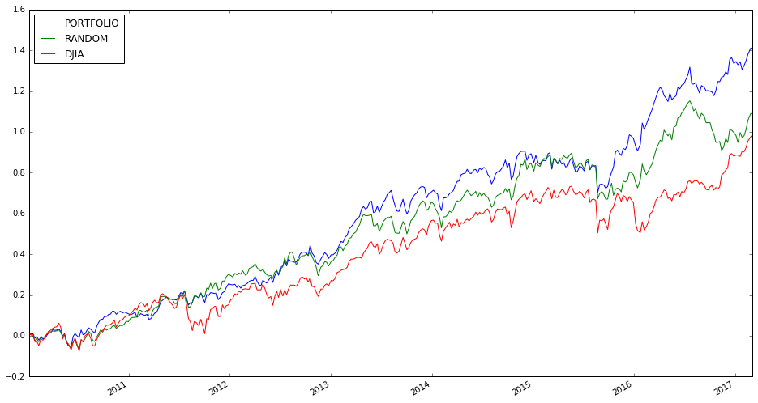

```python
prices = data.get("PRICE").copy()
prices["CASH"] = 1.0

portfolio = agent.get_portfolio()
portfolio_weights = portfolio.get_portfolio_weights()
portfolio_returns = portfolio.calculate_portfolio_returns(prices)
cum_portfolio_returns = (portfolio_returns + 1).cumprod() - 1

random_portfolio = random_agent.get_portfolio()
random_portfolio_weights = random_portfolio.get_portfolio_weights().ix[portfolio_weights.index]
random_portfolio_returns = random_portfolio.calculate_portfolio_returns(prices).ix[portfolio_returns.index]
cum_random_portfolio_returns = (random_portfolio_returns + 1).cumprod() - 1

djia = pd.read_csv("{}/DJIA_PRICE.csv".format(path), index_col=0, parse_dates=True)\
        .ix[portfolio_returns.index].fillna(method='ffill')['DJIA']
djia_returns = (djia / djia.shift(1) - 1)[1:];
cum_djia_returns = (djia_returns + 1).cumprod() - 1

cum_returns = pd.DataFrame(columns=["PORTFOLIO", "RANDOM", "DJIA"], index=cum_portfolio_returns.index[1:])
cum_returns["PORTFOLIO"] = cum_portfolio_returns
cum_returns["RANDOM"] = cum_random_portfolio_returns
cum_returns["DJIA"] = cum_djia_returns

cum_returns.plot(figsize=(16,9))
```

### Portfolio Risk

The portfolio risk is approximated by using a rolling standard deviation of both portfolio and benchmark.

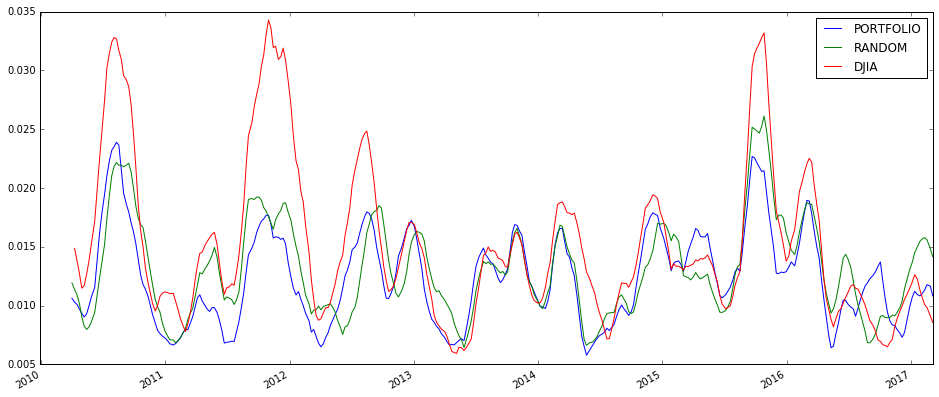

```python
rolling_std = pd.DataFrame(columns=["PORTFOLIO", "RANDOM", "DJIA"])
rolling_std['PORTFOLIO'] = portfolio_returns.rolling(rebalance_frequency).apply(lambda r: r.std())
rolling_std['RANDOM'] = random_portfolio_returns.rolling(rebalance_frequency).apply(lambda r: r.std())
rolling_std['DJIA'] = djia_returns.rolling(rebalance_frequency).apply(lambda r: r.std())

rolling_std.rolling(10).mean().plot(figsize=(16, 7))
```

### Assets Held

Below chart shows the number of assets the portfolio held through time, showing that on average 20 assets were held in the portfolio with low points of 9 assets and maximum of 29 assets.

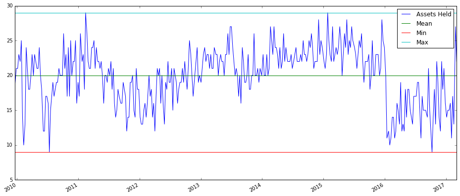

```python
weights = agent.get_portfolio().get_portfolio_weights().copy()

weights_plot = pd.DataFrame(columns=['Assets Held', 'Mean', 'Min', 'Max'])
weights_plot['Assets Held'] = weights.apply(lambda s: s.apply(lambda v: 1 if v > 0 else 0)).sum(axis=1)
weights_plot['Mean'] = weights_plot['Assets Held'].mean()
weights_plot['Min'] = weights_plot['Assets Held'].min()
weights_plot['Max'] = weights_plot['Assets Held'].max()

weights_plot.plot(figsize=(16, 7))
```

### Sharpe Ratio

The overall sharpe ratio for portfolio and benchmark gives an indication of the risk adjusted return achieved over the trading period. We find that the portfolio could achieve a higher Sharpe Ratio compared to the benchmark and the random portfolio.

```python
portfolio_sharpe = ((portfolio_returns + 1).cumprod() - 1)[-1] / portfolio_returns.std()
random_sharpe = ((random_portfolio_returns + 1).cumprod() - 1)[-1] / random_portfolio_returns.std()
djia_sharpe = ((djia_returns + 1).cumprod() - 1)[-1] / djia_returns.std()

print("Portfolio Sharpe: {}".format(portfolio_sharpe))
print("Random Sharpe: {}".format(random_sharpe))
print("DJIA Sharpe: {}".format(djia_sharpe))
```

```
Portfolio Sharpe: 94.3112590503
Random Sharpe: 68.9346604846
DJIA Sharpe: 51.4378022608
```

## Outlook

This capstone project has demonstrated an application of Q-Learning as a trading agent by creating a learner that makes buy and sell recommendations and creates minimum variance optimised portfolios through time. For that purpose price based as well as corporate fundamental data was used. The output demonstrated that the trading agent could achieve higher returns over a trading period of 7 years.

For the purpose of this project several real life complications were relaxed and assumptions made (see above). A more realistic version of this trading agent would one by one incorporate these complications and evaluate the behaviour of the agent.

Further the state space for the agent can be elaborated. As discussed above for each fundamental ratio category one representative ration was chosen. This can be improved by utilising more than one ratio per category and combining these using a weighted average. Further technical indicators can be added as well.